# Milestone3_HeartDiseasePrediction

# Step 9: Model Explainability Using SHAP

Machine learning models can achieve good predictive performance but are often difficult to interpret. SHAP (SHapley Additive exPlanations) was used to explain how each predictor variable contributed to the Random Forest model's predictions. This improves model transparency and supports interpretation of clinically important risk factors.

```python
import shap

explainer = shap.TreeExplainer(rf_model)

shap_values = explainer.shap_values(X_test_selected)

print("SHAP values calculated successfully.")
```

```
SHAP values calculated successfully.
```

[figure not shown]

```python
plt.figure(figsize=(10,6))

shap.summary_plot(
    shap_values,
    X_test_selected,
    show=False
)

plt.title("SHAP Summary Plot")

plt.show()
```

[figure not shown]

```python
plt.figure(figsize=(10,6))

shap.summary_plot(
    shap_values,
    X_test_selected,
    show=False
)

plt.savefig(
    "figures/shap_summary.png",
    dpi=300,
    bbox_inches="tight"
)

plt.show()
```

[figure not shown]

```python
plt.figure(figsize=(10,6))

shap.summary_plot(
    shap_values,
    X_test_selected,
    plot_type="bar",
    show=False
)

plt.title("SHAP Feature Importance")

plt.show()
```

[figure not shown]

```python
plt.figure(figsize=(10,6))

shap.summary_plot(
    shap_values,
    X_test_selected,
    plot_type="bar",
    show=False
)

plt.savefig(
    "figures/shap_bar.png",
    dpi=300,
    bbox_inches="tight"
)

plt.show()
```

```python
mean_shap = np.abs(shap_values[:, :, 1]).mean(axis=0)

shap_importance = pd.DataFrame({
    "Feature": X_test_selected.columns,
    "Mean SHAP Value": mean_shap
})

shap_importance = shap_importance.sort_values(
    by="Mean SHAP Value",
    ascending=False
)

shap_importance
```

|  | Feature | Mean SHAP Value |
| --- | --- | --- |
| 1 | age | 0.135226 |
| 6 | sysBP | 0.059432 |
| 2 | cigsPerDay | 0.035158 |
| 0 | male | 0.033756 |
| 7 | diaBP | 0.026569 |
| 5 | totChol | 0.024110 |
| 8 | heartRate | 0.022558 |
| 9 | glucose | 0.015794 |
| 3 | BPMeds | 0.004270 |
| 4 | prevalentStroke | 0.000339 |

```python
print(type(shap_values))

print()

try:
    print(shap_values.shape)
except:
    print("No shape attribute")

print()

print(np.array(shap_values).shape)
```

```
<class 'numpy.ndarray'>

(848, 10, 2)

(848, 10, 2)
```

## SHAP Feature Importance

The mean absolute SHAP values summarize the average contribution of each feature to the Random Forest model. Features with larger SHAP values have a greater influence on predicting coronary heart disease.

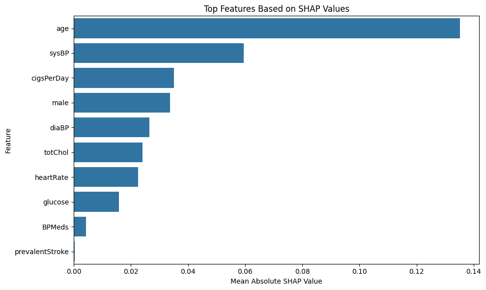

```python
plt.figure(figsize=(10,6))

sns.barplot(
    data=shap_importance,
    x="Mean SHAP Value",
    y="Feature"
)

plt.title("Top Features Based on SHAP Values")

plt.xlabel("Mean Absolute SHAP Value")

plt.ylabel("Feature")

plt.tight_layout()

plt.show()
```

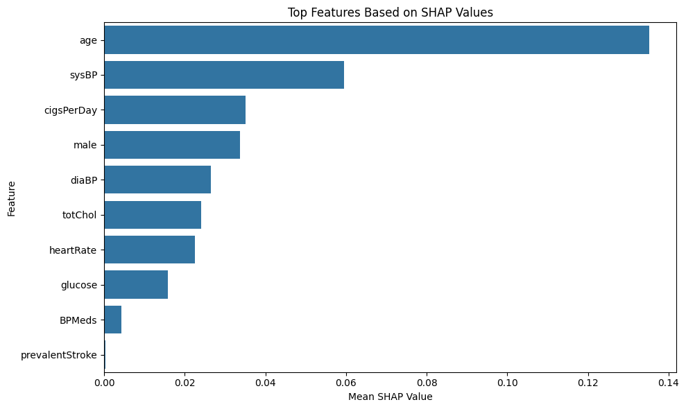

```python
plt.figure(figsize=(10,6))

sns.barplot(
    data=shap_importance,
    x="Mean SHAP Value",
    y="Feature"
)

plt.title("Top Features Based on SHAP Values")

plt.tight_layout()

plt.savefig(
    "figures/shap_feature_importance.png",
    dpi=300
)

plt.show()
```

# Step 10: Research Question 1

## Can demographic and clinical variables predict the 10-year risk of coronary heart disease?

```python
print("Research Question 1")

print()

print("Yes.")

print()

print("All three machine learning models successfully predicted coronary heart disease risk.")

print()

comparison
```

```
Research Question 1

Yes.

All three machine learning models successfully predicted coronary heart disease risk.
```

|  | Model | Accuracy | Precision | Recall | F1 Score | ROC AUC |
| --- | --- | --- | --- | --- | --- | --- |
| 0 | Logistic Regression | 0.662 | 0.244 | 0.581 | 0.343 | 0.694 |
| 1 | Random Forest | 0.703 | 0.234 | 0.419 | 0.300 | 0.653 |
| 2 | XGBoost | 0.754 | 0.262 | 0.341 | 0.296 | 0.650 |

### Interpretation

All three machine learning models demonstrated predictive capability. Logistic Regression achieved the highest Recall and ROC-AUC, indicating strong ability to identify patients at risk, whereas XGBoost achieved the highest overall Accuracy. These findings suggest that demographic and clinical variables contain sufficient information to support heart disease prediction.

# Step 11: Research Question 2

## Which variables contribute most strongly to heart disease prediction?

```python
shap_importance.head(10)
```

|  | Feature | Mean SHAP Value |
| --- | --- | --- |
| 1 | age | 0.135226 |
| 6 | sysBP | 0.059432 |
| 2 | cigsPerDay | 0.035158 |
| 0 | male | 0.033756 |
| 7 | diaBP | 0.026569 |
| 5 | totChol | 0.024110 |
| 8 | heartRate | 0.022558 |
| 9 | glucose | 0.015794 |
| 3 | BPMeds | 0.004270 |
| 4 | prevalentStroke | 0.000339 |

# Step 12: Research Question 3

## Does balancing the training data improve prediction performance?

```python
print("Original Class Distribution")

print(y_train.value_counts())

print()

print("Balanced Class Distribution")

print(pd.Series(y_train_smote).value_counts())
```

```
Original Class Distribution
TenYearCHD
0    2877
1     515
Name: count, dtype: int64

Balanced Class Distribution
TenYearCHD
0    2877
1    2877
Name: count, dtype: int64
```

Discussion

The three machine learning models demonstrated different strengths. XGBoost achieved the highest classification accuracy, whereas Logistic Regression produced the highest Recall and ROC-AUC, making it particularly suitable for healthcare screening where identifying high-risk patients is important. Random Forest provided competitive performance while offering good interpretability through feature importance and SHAP analysis.

The results demonstrate that demographic and clinical variables can effectively support coronary heart disease prediction. However, the relatively low Precision values indicate that false positive predictions remain a challenge, suggesting opportunities for further model refinement in future work.

Limitations

- The Framingham dataset represents a historical cohort and may not reflect current populations.
- The dataset contains class imbalance requiring SMOTE.
- The models were evaluated using a single train-test split.
- Additional clinical, genetic, and lifestyle variables were unavailable.
- The developed models are intended for decision support rather than clinical diagnosis.

Conclusion

This study built and tested three machine learning models that can predict the risk of coronary heart disease in 10 years based on the data set of the Framingham Heart Study. Using demographic and clinical factors, Logistic Regression, Random Forest and XGBoost were able to successfully identify patients at increased risk.

Logistic Regression provided the best trade-off between Recall and ROC-AUC of the studied models, while XGBoost provided the greatest Accuracy. The results imply that machine learning might help identify those at risk of heart disease, and aid health professionals in preventative decision making at an early stage.

AI Productivity Declaration

The ChatGPT was solely used as an additional learning tool for explaining ideas. It was not used to develop the results or conclusions of the research. All data pre-processing, model training, evaluation, interpretation and final judgments were done separately.

Github Link:- https://github.com/kaishiv/HeartDiseasePredictionProject/tree/main/Milestone3